# Pipho_K_Assignment06

Krista Pipho, kp275

March 15, 2021

## Multiple Regression

Load in required packages

### Problem 1:

Load the HistData package and examine the GaltonFamilies data set. Using cowplot create a single figure with three sub-figures: A) the distribution of height for all offspring; B) overlapping density plots giving the height distributions for male and female offspring separately; C) boxplots of height for male and female children separately

```r
glimpse(GaltonFamilies)
```

```
## Rows: 934
## Columns: 8
## $ family          <fct> 001, 001, 001, 001, 002, 002, 002, 002, 003, 003, 0...
## $ father          <dbl> 78.5, 78.5, 78.5, 78.5, 75.5, 75.5, 75.5, 75.5, 75....
## $ mother          <dbl> 67.0, 67.0, 67.0, 67.0, 66.5, 66.5, 66.5, 66.5, 64....
## $ midparentHeight <dbl> 75.43, 75.43, 75.43, 75.43, 73.66, 73.66, 73.66, 73...
## $ children        <int> 4, 4, 4, 4, 4, 4, 4, 4, 2, 2, 5, 5, 5, 5, 5, 6, 6, ...
## $ childNum        <int> 1, 2, 3, 4, 1, 2, 3, 4, 1, 2, 1, 2, 3, 4, 5, 1, 2, ...
## $ gender          <fct> male, female, female, female, male, male, female, f...
## $ childHeight     <dbl> 73.2, 69.2, 69.0, 69.0, 73.5, 72.5, 65.5, 65.5, 71....
```

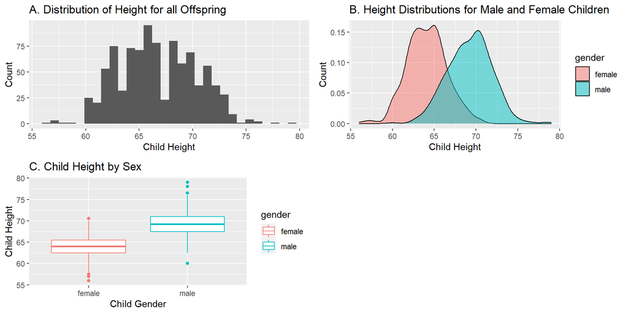

```r
distribution_of_height <- ggplot(GaltonFamilies, aes(x = childHeight)) + geom_histogram() + labs(x = "Child Height", y = "Count", title = "A. Distribution of Height for all Offspring")

overlapping_density <- ggplot(GaltonFamilies) + geom_density(aes(x = childHeight, fill = gender), alpha = .5) + labs(x = "Child Height", y = "Count", title = "B. Height Distributions for Male and Female Children")

m_f_boxplot <- ggplot(GaltonFamilies) + geom_boxplot(aes(x = gender, y = childHeight, color = gender)) + labs(x = "Child Gender", y = "Child Height", title = "C. Child Height by Sex")

composite_plot_1 <- plot_grid(distribution_of_height, overlapping_density, m_f_boxplot, labels("A.","B.","C."))

composite_plot_1
```

### Problem 2:

Create two 3D scatter plots, one each for male and female offspring, showing the relationship between offspring height and mother and fathers height.

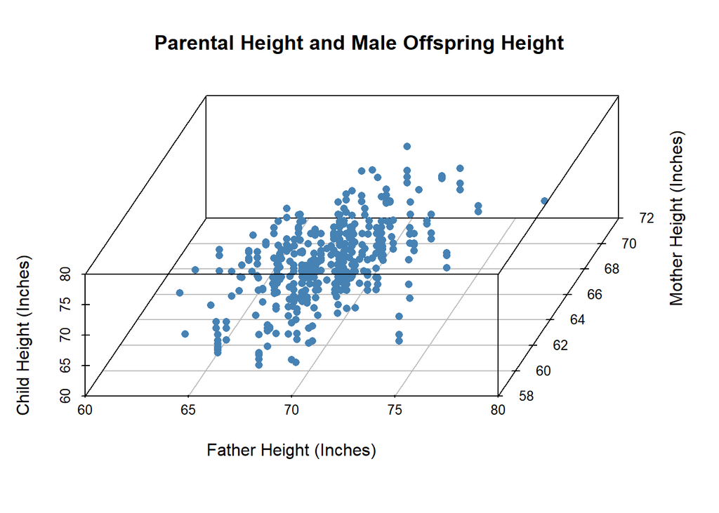

```r
galton_male = filter(GaltonFamilies, gender == 'male')

scatterplot3d(galton_male$father, galton_male$mother, galton_male$childHeight, pch = 16, color = "steelblue", angle = 75, main = "Parental Height and Male Offspring Height", xlab = "Father Height (Inches)", ylab = "Mother Height (Inches)", zlab = "Child Height (Inches)")
```

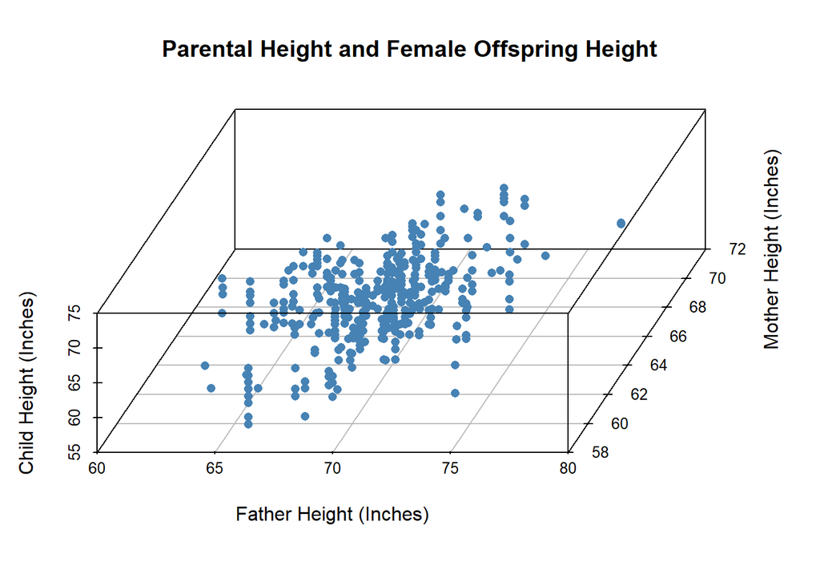

```r
galton_female = filter(GaltonFamilies, gender == 'female')

scatterplot3d(galton_female$father, galton_female$mother, galton_female$childHeight, pch = 16, color = "steelblue", angle = 75, main = "Parental Height and Female Offspring Height", xlab = "Father Height (Inches)", ylab = "Mother Height (Inches)", zlab = "Child Height (Inches)")
```

### Problem 3:

For male offspring, using the lm() function, fit a multiple regression of offspring height on father and mother's height. Write out the predicted model with the corresponding coefficients in the form O^male=a+b1F+b2M where O, F and M are offspring, father's, and mother's height. What fraction of the variation in offspring height does the model capture?

```r
male_children_model <- lm(childHeight~father+mother, galton_male)
summary(male_children_model)
```

```
##
## Call:
## lm(formula = childHeight ~ father + mother, data = galton_male)
##
## Residuals:
##     Min      1Q  Median      3Q     Max
## -9.5389 -1.5534  0.2212  1.5060  9.0880
##
## Coefficients:
##             Estimate Std. Error t value Pr(>|t|)
## (Intercept) 19.31281    4.09503   4.716 3.16e-06 ***
## father       0.41756    0.04561   9.154  < 2e-16 ***
## mother       0.32877    0.04530   7.258 1.61e-12 ***
## ---
## Signif. codes:  0 '***' 0.001 '**' 0.01 '*' 0.05 '.' 0.1 ' ' 1
##
## Residual standard error: 2.295 on 478 degrees of freedom
## Multiple R-squared:  0.2379, Adjusted R-squared:  0.2347
## F-statistic: 74.62 on 2 and 478 DF,  p-value: < 2.2e-16
```

The predicted model for relationship between male offspring height and parental hight is as follows:

$$\hat{O}_{male} = 19.3128 + 0.4176F + 0.3288M$$
Where O, F and M are offspring, father's, and mother's height respectively. This model captures 23.8% of the variation in male offspring height.

### Problem 4:

For female offspring, using the lm() function, fit a multiple regression of offspring height on father and mother's height. Write out the predicted model with the corresponding coefficients in the form O^female=a+b1F+b2M where O, F and M are offspring, father's, and mother's height. What fraction of the variation in offspring height does the model capture?

```r
female_children_model <- lm(childHeight~father+mother, galton_female)
summary(female_children_model)
```

```
##
## Call:
## lm(formula = childHeight ~ father + mother, data = galton_female)
##
## Residuals:
##     Min      1Q  Median      3Q     Max
## -6.3754 -1.4035 -0.0445  1.4107  6.9251
##
## Coefficients:
##             Estimate Std. Error t value Pr(>|t|)
## (Intercept) 18.83358    3.60947   5.218 2.77e-07 ***
## father       0.37254    0.03591  10.374  < 2e-16 ***
## mother       0.30348    0.04208   7.212 2.35e-12 ***
## ---
## Signif. codes:  0 '***' 0.001 '**' 0.01 '*' 0.05 '.' 0.1 ' ' 1
##
## Residual standard error: 2.02 on 450 degrees of freedom
## Multiple R-squared:  0.2681, Adjusted R-squared:  0.2649
## F-statistic: 82.44 on 2 and 450 DF,  p-value: < 2.2e-16
```

### Problem 5:

What is the predicted height of a male child, if the mother was 5 ft tall and the father was 6 ft tall? What is the predicted height of a female child from the same parents?

```r
male_child_predicted_height <- (19.3128 + 0.4176*72 + 0.3288*60)/12


female_child_predicted_height <- (18.83358 + 0.37254*72 + 0.30348*60)/12


print(paste("A six foot tall father and five foot tall mother are predicted to have a ", male_child_predicted_height, " foot tall male child or a ", female_child_predicted_height, " foot tall female child."))
```

```
## [1] "A six foot tall father and five foot tall mother are predicted to have a  5.759  foot tall male child or a  5.322105  foot tall female child."
```